# Paige Duffin Coding Exercise

## Loading and Checking Data

#### 1. Check if `dslabs` is already installed

(using new `%in%` oporator I learned in chapter 3 of the R Basics book!):

```r
("dslabs") %in% installed.packages()
```

```
## [1] TRUE
```

Yes, its already installed.

#### 2. Load `dslabs` package.

```r
library(dslabs)
```

#### 3. We’re using a dataset within the package `dslabs` called `gapminder`. Pull up the help page for the data to see what it contains:

```r
help("gapminder")
```

Highlights of R Documentation on `gapminder`

- **Description:** Health and income outcomes for 184 countries from 1960 to 2016. Also includes two character vectors, oecd and opec, with the names of OECD and OPEC countries from 2016.
- **Format:** An object of class `data.frame`.

#### 4. Inspect structure of the data frame.

```r
str(gapminder)
```

```
## 'data.frame':    10545 obs. of  9 variables:
##  $ country         : Factor w/ 185 levels "Albania","Algeria",..: 1 2 3 4 5 6 7 8 9 10 ...
##  $ year            : int  1960 1960 1960 1960 1960 1960 1960 1960 1960 1960 ...
##  $ infant_mortality: num  115.4 148.2 208 NA 59.9 ...
##  $ life_expectancy : num  62.9 47.5 36 63 65.4 ...
##  $ fertility       : num  6.19 7.65 7.32 4.43 3.11 4.55 4.82 3.45 2.7 5.57 ...
##  $ population      : num  1636054 11124892 5270844 54681 20619075 ...
##  $ gdp             : num  NA 1.38e+10 NA NA 1.08e+11 ...
##  $ continent       : Factor w/ 5 levels "Africa","Americas",..: 4 1 1 2 2 3 2 5 4 3 ...
##  $ region          : Factor w/ 22 levels "Australia and New Zealand",..: 19 11 10 2 15 21 2 1 22 21 ...
```

#### 5. Inspect summary of the data frame:

```r
summary(gapminder)
```

```
##                 country           year      infant_mortality
##  Albania            :   57   Min.   :1960   Min.   :  1.50
##  Algeria            :   57   1st Qu.:1974   1st Qu.: 16.00
##  Angola             :   57   Median :1988   Median : 41.50
##  Antigua and Barbuda:   57   Mean   :1988   Mean   : 55.31
##  Argentina          :   57   3rd Qu.:2002   3rd Qu.: 85.10
##  Armenia            :   57   Max.   :2016   Max.   :276.90
##  (Other)            :10203                  NA's   :1453
##  life_expectancy   fertility       population             gdp
##  Min.   :13.20   Min.   :0.840   Min.   :3.124e+04   Min.   :4.040e+07
##  1st Qu.:57.50   1st Qu.:2.200   1st Qu.:1.333e+06   1st Qu.:1.846e+09
##  Median :67.54   Median :3.750   Median :5.009e+06   Median :7.794e+09
##  Mean   :64.81   Mean   :4.084   Mean   :2.701e+07   Mean   :1.480e+11
##  3rd Qu.:73.00   3rd Qu.:6.000   3rd Qu.:1.523e+07   3rd Qu.:5.540e+10
##  Max.   :83.90   Max.   :9.220   Max.   :1.376e+09   Max.   :1.174e+13
##                  NA's   :187     NA's   :185         NA's   :2972
##     continent                region
##  Africa  :2907   Western Asia   :1026
##  Americas:2052   Eastern Africa : 912
##  Asia    :2679   Western Africa : 912
##  Europe  :2223   Caribbean      : 741
##  Oceania : 684   South America  : 684
##                  Southern Europe: 684
##                  (Other)        :5586
```

#### 6. Determine what type of object `gapminder` is (even though we already read that it was a data frame in the R documentation file- just double checking!).

```r
class(gapminder)
```

```
## [1] "data.frame"
```

## Processing Data

#### 7. Assign only the African countries to a new variable called `africadata`.

First inspecting what all the continent levels are.

```r
levels(gapminder$continent)
```

```
## [1] "Africa"   "Americas" "Asia"     "Europe"   "Oceania"
```

Now creating new variable for “Africa” continent data.

```r
africadata <- gapminder[gapminder$continent %in% "Africa",]
africadata
```

|  | country | year | infant_mortality | life_expectancy | fertility | population | gdp | continent | region |
| --- | --- | --- | --- | --- | --- | --- | --- | --- | --- |
| 2 | Algeria | 1960 | 148.2 | 47.50 | 7.65 | 11124892 | 13828152297 | Africa | Northern Africa |
| 3 | Angola | 1960 | 208.0 | 35.98 | 7.32 | 5270844 | NA | Africa | Middle Africa |
| 18 | Benin | 1960 | 186.9 | 38.29 | 6.28 | 2431620 | 621797131 | Africa | Western Africa |
| 22 | Botswana | 1960 | 115.5 | 50.34 | 6.62 | 524029 | 124460933 | Africa | Southern Africa |
| 26 | Burkina Faso | 1960 | 161.3 | 35.21 | 6.29 | 4829291 | 596612183 | Africa | Western Africa |
| 27 | Burundi | 1960 | 145.1 | 40.58 | 6.95 | 2786740 | 341126765 | Africa | Eastern Africa |
| 29 | Cameroon | 1960 | 166.9 | 43.46 | 5.65 | 5361367 | 2537944080 | Africa | Middle Africa |
| 31 | Cape Verde | 1960 | NA | 50.12 | 6.89 | 202316 | NA | Africa | Western Africa |
| 32 | Central African Republic | 1960 | 165.5 | 37.43 | 5.84 | 1503501 | 534982718 | Africa | Middle Africa |
| 33 | Chad | 1960 | NA | 40.95 | 6.25 | 3002596 | 750173439 | Africa | Middle Africa |

[output cut: 2897 more lines]

#### 8. Inspect structure and summary info for `africadata`:

```r
str(africadata)
```

```
## 'data.frame':    2907 obs. of  9 variables:
##  $ country         : Factor w/ 185 levels "Albania","Algeria",..: 2 3 18 22 26 27 29 31 32 33 ...
##  $ year            : int  1960 1960 1960 1960 1960 1960 1960 1960 1960 1960 ...
##  $ infant_mortality: num  148 208 187 116 161 ...
##  $ life_expectancy : num  47.5 36 38.3 50.3 35.2 ...
##  $ fertility       : num  7.65 7.32 6.28 6.62 6.29 6.95 5.65 6.89 5.84 6.25 ...
##  $ population      : num  11124892 5270844 2431620 524029 4829291 ...
##  $ gdp             : num  1.38e+10 NA 6.22e+08 1.24e+08 5.97e+08 ...
##  $ continent       : Factor w/ 5 levels "Africa","Americas",..: 1 1 1 1 1 1 1 1 1 1 ...
##  $ region          : Factor w/ 22 levels "Australia and New Zealand",..: 11 10 20 17 20 5 10 20 10 10 ...
```

Yes! I have the anticipated 2907 obs., down from 10545.

```r
summary(africadata)
```

```
##          country          year      infant_mortality life_expectancy
##  Algeria     :  57   Min.   :1960   Min.   : 11.40   Min.   :13.20
##  Angola      :  57   1st Qu.:1974   1st Qu.: 62.20   1st Qu.:48.23
##  Benin       :  57   Median :1988   Median : 93.40   Median :53.98
##  Botswana    :  57   Mean   :1988   Mean   : 95.12   Mean   :54.38
##  Burkina Faso:  57   3rd Qu.:2002   3rd Qu.:124.70   3rd Qu.:60.10
##  Burundi     :  57   Max.   :2016   Max.   :237.40   Max.   :77.60
##  (Other)     :2565                  NA's   :226
##    fertility       population             gdp               continent
##  Min.   :1.500   Min.   :    41538   Min.   :4.659e+07   Africa  :2907
##  1st Qu.:5.160   1st Qu.:  1605232   1st Qu.:8.373e+08   Americas:   0
##  Median :6.160   Median :  5570982   Median :2.448e+09   Asia    :   0
##  Mean   :5.851   Mean   : 12235961   Mean   :9.346e+09   Europe  :   0
##  3rd Qu.:6.860   3rd Qu.: 13888152   3rd Qu.:6.552e+09   Oceania :   0
##  Max.   :8.450   Max.   :182201962   Max.   :1.935e+11
##  NA's   :51      NA's   :51          NA's   :637
##                        region
##  Eastern Africa           :912
##  Western Africa           :912
##  Middle Africa            :456
##  Northern Africa          :342
##  Southern Africa          :285
##  Australia and New Zealand:  0
##  (Other)                  :  0
```

Looks good!

#### 9. Subset the `africadata` data again so that it only contains `infant_mortality` and `life_expectancy` data.

I’m naming this new object `infmort_lifexp`.

```r
infmort <- africadata$infant_mortality
lifexp <- africadata$life_expectancy
infmort_lifexp <- data.frame("infant_mortality" = infmort, "life_expectancy" = lifexp)
head(infmort_lifexp)
```

|  | infant_mortality | life_expectancy |
| --- | --- | --- |
| 1 | 148.2 | 47.50 |
| 2 | 208.0 | 35.98 |
| 3 | 186.9 | 38.29 |
| 4 | 115.5 | 50.34 |
| 5 | 161.3 | 35.21 |
| 6 | 145.1 | 40.58 |

#### 10. Subset the `africadata` data a second time so that it only contains `population` and `life_expectancy` data.

I’m naming this new object `pop_lifexp`.

```r
popsize <- africadata$population
lifexp <- africadata$life_expectancy
pop_lifexp <- data.frame("population" = popsize, "life_expectancy" = lifexp)
head(pop_lifexp)
```

|  | population | life_expectancy |
| --- | --- | --- |
| 1 | 11124892 | 47.50 |
| 2 | 5270844 | 35.98 |
| 3 | 2431620 | 38.29 |
| 4 | 524029 | 50.34 |
| 5 | 4829291 | 35.21 |
| 6 | 2786740 | 40.58 |

#### 11. Inspect both new variables.

```r
str(infmort_lifexp)
```

```
## 'data.frame':    2907 obs. of  2 variables:
##  $ infant_mortality: num  148 208 187 116 161 ...
##  $ life_expectancy : num  47.5 36 38.3 50.3 35.2 ...
```

```r
summary(infmort_lifexp)
```

```
##  infant_mortality life_expectancy
##  Min.   : 11.40   Min.   :13.20
##  1st Qu.: 62.20   1st Qu.:48.23
##  Median : 93.40   Median :53.98
##  Mean   : 95.12   Mean   :54.38
##  3rd Qu.:124.70   3rd Qu.:60.10
##  Max.   :237.40   Max.   :77.60
##  NA's   :226
```

```r
str(pop_lifexp)
```

```
## 'data.frame':    2907 obs. of  2 variables:
##  $ population     : num  11124892 5270844 2431620 524029 4829291 ...
##  $ life_expectancy: num  47.5 36 38.3 50.3 35.2 ...
```

```r
summary(pop_lifexp)
```

```
##    population        life_expectancy
##  Min.   :    41538   Min.   :13.20
##  1st Qu.:  1605232   1st Qu.:48.23
##  Median :  5570982   Median :53.98
##  Mean   : 12235961   Mean   :54.38
##  3rd Qu.: 13888152   3rd Qu.:60.10
##  Max.   :182201962   Max.   :77.60
##  NA's   :51
```

## Plotting

Instructions pulled right from [MADA Course GitHub](https://andreashandel.github.io/MADAcourse/Exercise_Coding.html): *Using the new variables you created, plot life expectancy as a function of infant mortality and as a function of population size. Make two separate plots. Use base R plot commands, i.e., the `plot` function. Plot the data as points. For the plot with population size on the x-axis, set the x-axis to a log scale.*

#### 12. Plot life expectancy as a function of infant mortality.

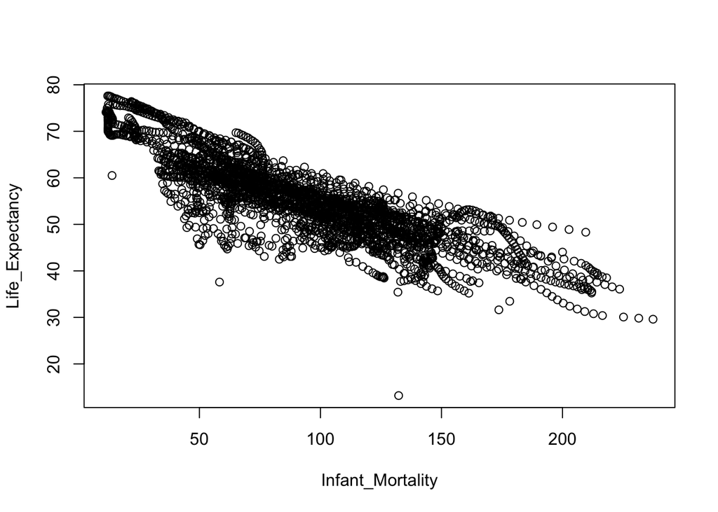

```r
Infant_Mortality <- infmort_lifexp$infant_mortality
Life_Expectancy <- infmort_lifexp$life_expectancy
plot(Infant_Mortality, Life_Expectancy)
```

#### 13. Plot life expectancy as a function of log(population size).

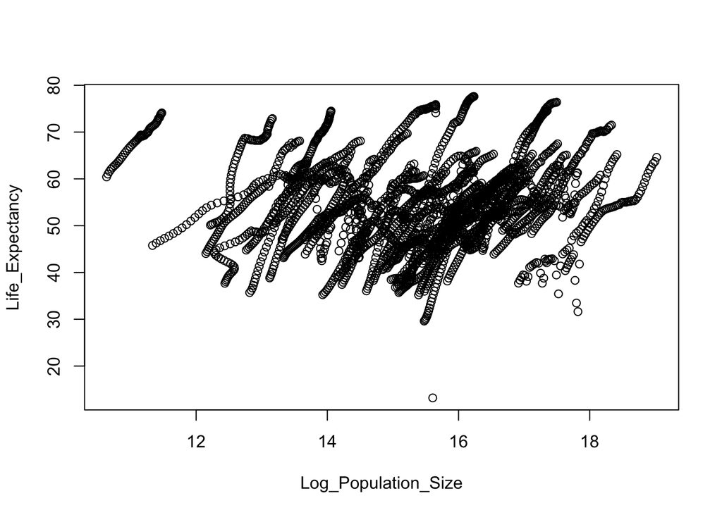

```r
Log_Population_Size <- log(pop_lifexp$population)
Life_Expectancy <- pop_lifexp$life_expectancy
plot(Log_Population_Size, Life_Expectancy)
```

#### 14. Interpreting results.

- Yes, I see a negative correlation between infant mortality and life expectancy. This is to be expected.
- No, I don’t really see a prominant positive correlation between log-normalized population size and life expectancy.
- Regarding the “streaks”:

```r
head(africadata)
```

|  | country | year | infant_mortality | life_expectancy | fertility | population | gdp | continent | region |
| --- | --- | --- | --- | --- | --- | --- | --- | --- | --- |
| 2 | Algeria | 1960 | 148.2 | 47.50 | 7.65 | 11124892 | 13828152297 | Africa | Northern Africa |
| 3 | Angola | 1960 | 208.0 | 35.98 | 7.32 | 5270844 | NA | Africa | Middle Africa |
| 18 | Benin | 1960 | 186.9 | 38.29 | 6.28 | 2431620 | 621797131 | Africa | Western Africa |
| 22 | Botswana | 1960 | 115.5 | 50.34 | 6.62 | 524029 | 124460933 | Africa | Southern Africa |
| 26 | Burkina Faso | 1960 | 161.3 | 35.21 | 6.29 | 4829291 | 596612183 | Africa | Western Africa |
| 27 | Burundi | 1960 | 145.1 | 40.58 | 6.95 | 2786740 | 341126765 | Africa | Eastern Africa |

I notice the “year” column. Was each country sampled more than one year? I’ll check by just isolating the data from one country.

```r
Algeria <- africadata[africadata$country %in% "Algeria",]
Algeria$year
```

```
##  [1] 1960 1961 1962 1963 1964 1965 1966 1967 1968 1969 1970 1971 1972 1973
## [15] 1974 1975 1976 1977 1978 1979 1980 1981 1982 1983 1984 1985 1986 1987
## [29] 1988 1989 1990 1991 1992 1993 1994 1995 1996 1997 1998 1999 2000 2001
## [43] 2002 2003 2004 2005 2006 2007 2008 2009 2010 2011 2012 2013 2014 2015
## [57] 2016
```

Yes! It was sampled yearly. Let me quickly see if just plotting Algeria creates the streaks I see.

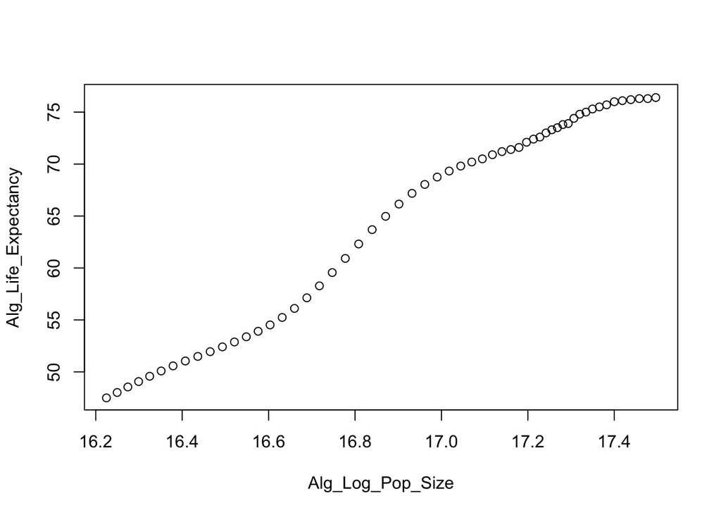

```r
Alg_pop <- Algeria$population
Alg_lifexp <- Algeria$life_expectancy
Alg_pop_lifexp <- data.frame("Algeria_population" = Alg_pop, "Algeria_life_expectancy" = Alg_lifexp)
Alg_Log_Pop_Size <- log(Alg_pop_lifexp$Algeria_population)
Alg_Life_Expectancy <- Alg_pop_lifexp$Algeria_life_expectancy
plot(Alg_Log_Pop_Size, Alg_Life_Expectancy)
```

Yes! That completely supports what I’d expect, given my hypothesis that the “streaks” are caused by data points across years for each country, as metrics like population size are expected to change gradually year to year.

## More Data Processing

#### 15. Determine which years have missing data for infant mortality.

```r
index_na <- is.na(africadata$infant_mortality)
africadata$year[index_na]
```

```
##   [1] 1960 1960 1960 1960 1960 1960 1960 1960 1960 1960 1961 1961 1961 1961
##  [15] 1961 1961 1961 1961 1961 1961 1961 1961 1961 1961 1961 1961 1961 1962
##  [29] 1962 1962 1962 1962 1962 1962 1962 1962 1962 1962 1962 1962 1962 1962
##  [43] 1962 1963 1963 1963 1963 1963 1963 1963 1963 1963 1963 1963 1963 1963
##  [57] 1963 1963 1963 1964 1964 1964 1964 1964 1964 1964 1964 1964 1964 1964
##  [71] 1964 1964 1964 1964 1965 1965 1965 1965 1965 1965 1965 1965 1965 1965
##  [85] 1965 1965 1965 1965 1966 1966 1966 1966 1966 1966 1966 1966 1966 1966
##  [99] 1966 1966 1966 1967 1967 1967 1967 1967 1967 1967 1967 1967 1967 1967
## [113] 1968 1968 1968 1968 1968 1968 1968 1968 1968 1968 1968 1969 1969 1969
## [127] 1969 1969 1969 1969 1970 1970 1970 1970 1970 1971 1971 1971 1971 1971
## [141] 1971 1972 1972 1972 1972 1972 1972 1973 1973 1973 1973 1973 1973 1974
## [155] 1974 1974 1974 1974 1975 1975 1975 1975 1975 1976 1976 1976 1977 1977
## [169] 1977 1978 1978 1979 1979 1980 1981 2016 2016 2016 2016 2016 2016 2016
## [183] 2016 2016 2016 2016 2016 2016 2016 2016 2016 2016 2016 2016 2016 2016
## [197] 2016 2016 2016 2016 2016 2016 2016 2016 2016 2016 2016 2016 2016 2016
## [211] 2016 2016 2016 2016 2016 2016 2016 2016 2016 2016 2016 2016 2016 2016
## [225] 2016 2016
```

Findings: Missing data in years 1960:1981, 2016

#### 16. Extracting only data from the year 2000. Inspect object.

```r
africa_2000 <- africadata[africadata$year %in% 2000,]
str(africa_2000)
```

```
## 'data.frame':    51 obs. of  9 variables:
##  $ country         : Factor w/ 185 levels "Albania","Algeria",..: 2 3 18 22 26 27 29 31 32 33 ...
##  $ year            : int  2000 2000 2000 2000 2000 2000 2000 2000 2000 2000 ...
##  $ infant_mortality: num  33.9 128.3 89.3 52.4 96.2 ...
##  $ life_expectancy : num  73.3 52.3 57.2 47.6 52.6 46.7 54.3 68.4 45.3 51.5 ...
##  $ fertility       : num  2.51 6.84 5.98 3.41 6.59 7.06 5.62 3.7 5.45 7.35 ...
##  $ population      : num  31183658 15058638 6949366 1736579 11607944 ...
##  $ gdp             : num  5.48e+10 9.13e+09 2.25e+09 5.63e+09 2.61e+09 ...
##  $ continent       : Factor w/ 5 levels "Africa","Americas",..: 1 1 1 1 1 1 1 1 1 1 ...
##  $ region          : Factor w/ 22 levels "Australia and New Zealand",..: 11 10 20 17 20 5 10 20 10 10 ...
```

```r
summary(africa_2000)
```

```
##          country        year      infant_mortality life_expectancy
##  Algeria     : 1   Min.   :2000   Min.   : 12.30   Min.   :37.60
##  Angola      : 1   1st Qu.:2000   1st Qu.: 60.80   1st Qu.:51.75
##  Benin       : 1   Median :2000   Median : 80.30   Median :54.30
##  Botswana    : 1   Mean   :2000   Mean   : 78.93   Mean   :56.36
##  Burkina Faso: 1   3rd Qu.:2000   3rd Qu.:103.30   3rd Qu.:60.00
##  Burundi     : 1   Max.   :2000   Max.   :143.30   Max.   :75.00
##  (Other)     :45
##    fertility       population             gdp               continent
##  Min.   :1.990   Min.   :    81154   Min.   :2.019e+08   Africa  :51
##  1st Qu.:4.150   1st Qu.:  2304687   1st Qu.:1.274e+09   Americas: 0
##  Median :5.550   Median :  8799165   Median :3.238e+09   Asia    : 0
##  Mean   :5.156   Mean   : 15659800   Mean   :1.155e+10   Europe  : 0
##  3rd Qu.:5.960   3rd Qu.: 17391242   3rd Qu.:8.654e+09   Oceania : 0
##  Max.   :7.730   Max.   :122876723   Max.   :1.329e+11
##
##                        region
##  Eastern Africa           :16
##  Western Africa           :16
##  Middle Africa            : 8
##  Northern Africa          : 6
##  Southern Africa          : 5
##  Australia and New Zealand: 0
##  (Other)                  : 0
```

Yes! I’ve now narrowed it down to 51 obs. of 9 variables.

## More Plotting

Create same plots as before with the full `africadata` set, now just with `africa_2000`.

#### 17. Plot life expectancy as a function of infant mortality in the year 2000.

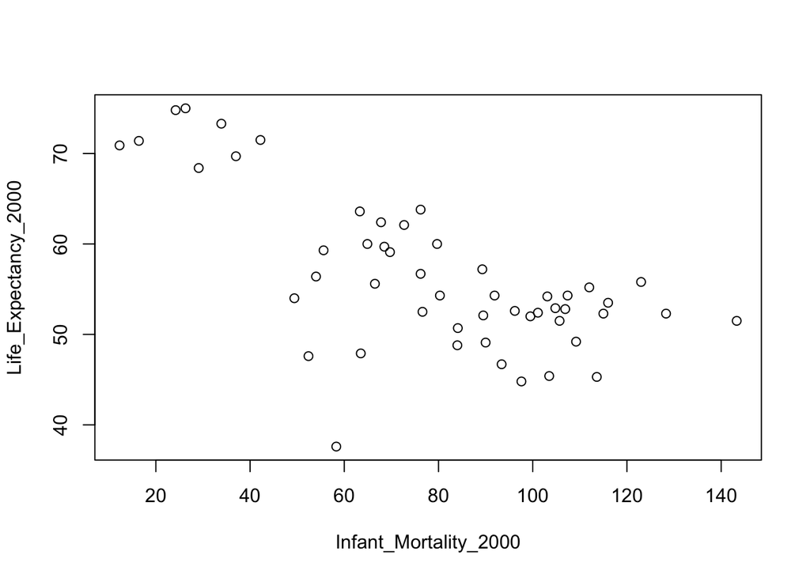

```r
Infant_Mortality_2000 <- africa_2000$infant_mortality
Life_Expectancy_2000 <- africa_2000$life_expectancy
plot(Infant_Mortality_2000, Life_Expectancy_2000)
```

#### 18. Plot life expectancy as a function of log(population size) in the year 2000.

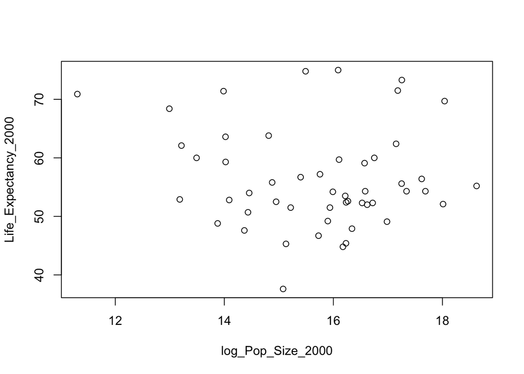

```r
log_Pop_Size_2000 <- log(africa_2000$population)
Life_Expectancy_2000 <- africa_2000$life_expectancy
plot(log_Pop_Size_2000, Life_Expectancy_2000)
```

## A Simple Fit

Use `lm` function to apply statistics to this data.

```r
?lm
```

Usage: `lm(formula, data, subset, weights, na.action, method = "qr", model = TRUE, x = FALSE, y = FALSE, qr = TRUE, singular.ok = TRUE, contrasts = NULL, offset, ...)`

#### 19. Fit life expectancy as the outcome and infant mortality as the predictor.

Note: `lm(outcome~predictor)`

```r
fit1 <- lm(Life_Expectancy_2000 ~ Infant_Mortality_2000)
summary(fit1)
```

```
##
## Call:
## lm(formula = Life_Expectancy_2000 ~ Infant_Mortality_2000)
##
## Residuals:
##      Min       1Q   Median       3Q      Max
## -22.6651  -3.7087   0.9914   4.0408   8.6817
##
## Coefficients:
##                       Estimate Std. Error t value Pr(>|t|)
## (Intercept)           71.29331    2.42611  29.386  < 2e-16 ***
## Infant_Mortality_2000 -0.18916    0.02869  -6.594 2.83e-08 ***
## ---
## Signif. codes:  0 '***' 0.001 '**' 0.01 '*' 0.05 '.' 0.1 ' ' 1
##
## Residual standard error: 6.221 on 49 degrees of freedom
## Multiple R-squared:  0.4701, Adjusted R-squared:  0.4593
## F-statistic: 43.48 on 1 and 49 DF,  p-value: 2.826e-08
```

p-value for fit1 is 2.82e-08.

Note: `lm(outcome~predictor)`.

Not sure if I should use log(Pop Size) or just Pop Size as the predictor, so I’m going to try both.

```r
Pop_Size_2000 <- africa_2000$population
fit2 <- lm(Life_Expectancy_2000 ~ Pop_Size_2000)
summary(fit2)
```

```
##
## Call:
## lm(formula = Life_Expectancy_2000 ~ Pop_Size_2000)
##
## Residuals:
##     Min      1Q  Median      3Q     Max
## -18.429  -4.602  -2.568   3.800  18.802
##
## Coefficients:
##                Estimate Std. Error t value Pr(>|t|)
## (Intercept)   5.593e+01  1.468e+00  38.097   <2e-16 ***
## Pop_Size_2000 2.756e-08  5.459e-08   0.505    0.616
## ---
## Signif. codes:  0 '***' 0.001 '**' 0.01 '*' 0.05 '.' 0.1 ' ' 1
##
## Residual standard error: 8.524 on 49 degrees of freedom
## Multiple R-squared:  0.005176,   Adjusted R-squared:  -0.01513
## F-statistic: 0.2549 on 1 and 49 DF,  p-value: 0.6159
```

```r
fit3 <- lm(Life_Expectancy_2000 ~ log_Pop_Size_2000)
summary(fit3)
```

```
##
## Call:
## lm(formula = Life_Expectancy_2000 ~ log_Pop_Size_2000)
##
## Residuals:
##     Min      1Q  Median      3Q     Max
## -19.113  -4.809  -1.554   3.907  18.863
##
## Coefficients:
##                   Estimate Std. Error t value Pr(>|t|)
## (Intercept)        65.3243    12.5203   5.217 3.65e-06 ***
## log_Pop_Size_2000  -0.5711     0.7943  -0.719    0.476
## ---
## Signif. codes:  0 '***' 0.001 '**' 0.01 '*' 0.05 '.' 0.1 ' ' 1
##
## Residual standard error: 8.502 on 49 degrees of freedom
## Multiple R-squared:  0.01044,    Adjusted R-squared:  -0.009755
## F-statistic: 0.517 on 1 and 49 DF,  p-value: 0.4755
```

Both fit2 and fit3 p-values (0.6159 and 0.4755, respectively) are well over that of fit1 (2.82e-08), so whether I use the log-normalized pop data or the raw pop data, the outcome is the same.

#### 21. Interpreting results.

Both fit2 and fit3 p-values (0.6159 and 0.4755, respectively) are well over that of fit1 (2.82e-08), so whether I use the log-normalized pop data or the raw pop data, the outcome is the same: **The linear models suggest that infant mortality is a significant predictor of life expectancy in Africa in 2000, while population size is not.** This conclusion makes sense based on the plots generated.